# Case study - The helix

# Helix

Suppose the trajectory of a moving particle can be described by the vector valued function
$$\mathbf{r} = \begin{bmatrix}
b t \\
a \cos{\left(t \right)} \\
a \sin{\left(t \right)} \\
\end{bmatrix}$$
where $a$ and $b$ are positive constants. The curve that is the image of this function is called a *helix* (the plural form of helix is *helices*). A helix is a spiral-like curve, where a curve moves around a central axis at a constant distance. It can be found in nature, such as in DNA structures, or in artificial objects like a coiled spring. The following figure shows two helices with different choices for $a$ and $b$.

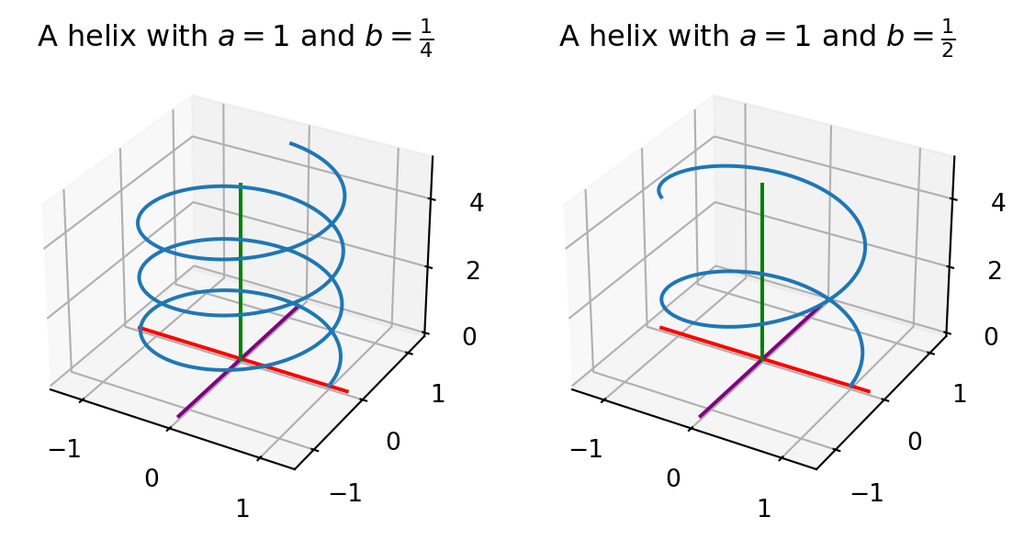

## The TNB frame

The *TNB frame*, also known as the *Frenet-Serret frame*, consists of three unit vectors that are orthogonal to one another:

- the unit tangent vector $\mathbf{T}$
- the principal unit normal vector $\mathbf{N}$
- the (unit) binormal vector $\mathbf{B}$

Together, these vectors form a natural coordinate system (indeed a *orthonormal basis* spanning the 3-dimensional space) that is particularly convenient for describing the motion of a point-like moving object.

Compute the unit tangent vector $\mathbf{T}$.

**Answer**

The unit tangent vector is given by
$$\mathbf{T} =
\frac{
\frac{d\mathbf{r}}{dt}
}{
\left\| \frac{d\mathbf{r}}{dt} \right\|
}
=
\begin{bmatrix}
\frac{b}{\sqrt{a^{2} + b^{2}}} \\
- \frac{a \sin{\left(t \right)}}{\sqrt{a^{2} + b^{2}}} \\
\frac{a \cos{\left(t \right)}}{\sqrt{a^{2} + b^{2}}} \\
\end{bmatrix}$$
This vector gives us the direction in which this particle moving.

Compute the principal unit normal vector $\mathbf{N}$.

**Answer**

The principal unit normal vector is given by
$$\mathbf{N} =
\frac{
\frac{d\mathbf{T}}{dt}
}{
\| \frac{d\mathbf{T}}{dt} \|
}
=
\begin{bmatrix}
0 \\
- \cos{\left(t \right)} \\
- \sin{\left(t \right)} \\
\end{bmatrix}$$

Compute the binormal vector $\mathbf{B}$.

**Answer**

The binormal vector is simply the cross product between $\mathbf{T}$ and $\mathbf{N}$, i.e.,
$$\mathbf{B} = \mathbf{T} \times \mathbf{N} =
\begin{bmatrix} \frac{b}{\sqrt{a^{2} + b^{2}}} \\ - \frac{a \sin{\left(t \right)}}{\sqrt{a^{2} + b^{2}}} \\ \frac{a \cos{\left(t \right)}}{\sqrt{a^{2} + b^{2}}}\end{bmatrix} \times
\begin{bmatrix} 0 \\ - \cos{\left(t \right)} \\ - \sin{\left(t \right)}\end{bmatrix}
=
\begin{bmatrix} \frac{a}{\sqrt{a^{2} + b^{2}}} \\ \frac{b \sin{\left(t \right)}}{\sqrt{a^{2} + b^{2}}} \\ - \frac{b \cos{\left(t \right)}}{\sqrt{a^{2} + b^{2}}}\end{bmatrix}$$

## Arc-length and arc-length parametrization

Compute the arc-length function $s(t) = \int_0^t \| \mathbf{r}'(u) \| du$.

**Answer**

$$\begin{aligned}
s(t) &=
\int_0^t \left\| \frac{d\mathbf{r}}{dt}(u) \right\| du =
\int_0^t \left\|
\begin{bmatrix} b \\ - a \sin{\left(u \right)} \\ a \cos{\left(u \right)}\end{bmatrix}
\right\| du
\\ &=
\int_0^t \left\|
\sqrt{a^{2} + b^{2}}
\right\| du
\\ &=
t \sqrt{a^{2} + b^{2}}
\end{aligned}$$

Find an arc-length parametrization for $\mathbf{r}$.

**Answer**

In the above, we have computed
$$s = t \sqrt{a^{2} + b^{2}}$$
Solve if this equation for $t$ and plug in the result into the original definition of $\mathbf{r}$, we get the arc-length parametrization
$$\mathbf{r}(s) =
\begin{bmatrix} \frac{b s}{\sqrt{a^{2} + b^{2}}} \\ a \cos{\left(\frac{s}{\sqrt{a^{2} + b^{2}}} \right)} \\ a \sin{\left(\frac{s}{\sqrt{a^{2} + b^{2}}} \right)}\end{bmatrix}$$

## Curvature and Torsion

Curvature and torsion are key characteristics that define a curve in three-dimensional space. Curvature quantifies the amount by which a curve bends at any given point. On the other hand, torsion measures the rate at which a curve is twisting out of the osculating plane.

Compute the curvature of this curve.

**Answer**

Using the arc-lengh parametrization, we can compute that
$$\mathbf{T}(s) =
\begin{bmatrix} \frac{b}{\sqrt{a^{2} + b^{2}}} \\ - \frac{a \sin{\left(\frac{s}{\sqrt{a^{2} + b^{2}}} \right)}}{\sqrt{a^{2} + b^{2}}} \\ \frac{a \cos{\left(\frac{s}{\sqrt{a^{2} + b^{2}}} \right)}}{\sqrt{a^{2} + b^{2}}}\end{bmatrix}$$
Therefore, the curvature can be computed as
$$\kappa =
\left\| \frac{d\mathbf{T}}{ds} \right\| =
\left\|
\begin{bmatrix} 0 \\ - \frac{a \cos{\left(\frac{s}{\sqrt{a^{2} + b^{2}}} \right)}}{a^{2} + b^{2}} \\ - \frac{a \sin{\left(\frac{s}{\sqrt{a^{2} + b^{2}}} \right)}}{a^{2} + b^{2}}\end{bmatrix}
\right\|
=
\frac{a}{a^{2} + b^{2}}$$
Notice that the curvature is a constant that is only dependent and $a$ and $b$ (but remain the same value anywhere on the helix). It is important to note that this answer assumes $a > 0$. Otherwise we have to replace $a$ in the numerator by $|a|$.

Compute the torsion of this curve.

**Answer**

Again, using the arc-length parametrization, we can compute the binormal and the principle unit normal vectors as
$$\mathbf{N}(s) =
\begin{bmatrix} 0 \\ - \cos{\left(\frac{s}{\sqrt{a^{2} + b^{2}}} \right)} \\ - \sin{\left(\frac{s}{\sqrt{a^{2} + b^{2}}} \right)}\end{bmatrix}
\quad\text{and}\quad
\mathbf{B}(s) =
\begin{bmatrix} \frac{a}{\sqrt{a^{2} + b^{2}}} \\ \frac{b \sin{\left(\frac{s}{\sqrt{a^{2} + b^{2}}} \right)}}{\sqrt{a^{2} + b^{2}}} \\ - \frac{b \cos{\left(\frac{s}{\sqrt{a^{2} + b^{2}}} \right)}}{\sqrt{a^{2} + b^{2}}}\end{bmatrix}
\quad\text{and}\quad
\frac{d\mathbf{B}}{ds} =
\begin{bmatrix} 0 \\ \frac{b \cos{\left(\frac{s}{\sqrt{a^{2} + b^{2}}} \right)}}{a^{2} + b^{2}} \\ \frac{b \sin{\left(\frac{s}{\sqrt{a^{2} + b^{2}}} \right)}}{a^{2} + b^{2}}\end{bmatrix}$$
Therefore, the torsion can be computed as
$$\tau = -\frac{d\mathbf{B}}{ds} \cdot \mathbf{N}(s) =
\frac{b}{a^{2} + b^{2}}$$
Notice that the torsion is also a constant that is only dependent and $a$ and $b$ (but remain the same value anywhere on the helix).

## Decomposition of acceleration

Let $\mathbf{a} = \frac{d^2 \mathbf{r}}{dt^2}$ be the acceleration vector. It can be decomposed into its tangential and normal components. That is,
$$\mathbf{a} = a_T \mathbf{T} + a_N \mathbf{N}$$
for some scalars $a_T$ (describing the tangential component) and $a_N$ (describing the normal component). They are not to be confused with the parameter $a$ we used to describe the shape of the helix.

Compute $a_T$ and $a_N$.

**Answer (direct computation)**

First, we can compute
$$\mathbf{a} =
\frac{d^2 \mathbf{r}}{dt^2} =
\frac{d}{dt} \left(
\frac{d}{dt} \begin{bmatrix} b t \\ a \cos{\left(t \right)} \\ a \sin{\left(t \right)}\end{bmatrix}
\right)
=
\frac{d}{dt} \begin{bmatrix} b \\ - a \sin{\left(t \right)} \\ a \cos{\left(t \right)}\end{bmatrix}
=
\begin{bmatrix} 0 \\ - a \cos{\left(t \right)} \\ - a \sin{\left(t \right)}\end{bmatrix}$$
The tangent component $a_T$ is simply the project of the acceleration vector $\mathbf{a}$ in the direction of $\mathbf{T}$. That is,
$$a_T = \mathbf{a} \cdot \mathbf{T} =
\begin{bmatrix} 0 \\ - a \cos{\left(t \right)} \\ - a \sin{\left(t \right)}\end{bmatrix}
\;\cdot\;
\begin{bmatrix} \frac{b}{\sqrt{a^{2} + b^{2}}} \\ - \frac{a \sin{\left(t \right)}}{\sqrt{a^{2} + b^{2}}} \\ \frac{a \cos{\left(t \right)}}{\sqrt{a^{2} + b^{2}}}\end{bmatrix}
=
0$$
This answer agrees with our intuition since we know that the scalar speed remains constant.

Similarly, $a_N$ is the projection of $\mathbf{a}$ in the direction of $\mathbf{N}$. That is,

$$a_N = \mathbf{a} \cdot \mathbf{N} =
\begin{bmatrix} 0 \\ - a \cos{\left(t \right)} \\ - a \sin{\left(t \right)}\end{bmatrix}
\;\cdot\;
\begin{bmatrix} 0 \\ - \cos{\left(t \right)} \\ - \sin{\left(t \right)}\end{bmatrix}
=
a$$

This give us the magnitude of the normal component of the acceleration, which is responsibie for turning.

**Answer (via scalar speed)**

Recall that scalar speed (i.e., $\| \mathbf{r}'(t) \|$, which is equivalent to $\frac{ds}{dt}$) is given by
$$\frac{ds}{dt} = \frac{d}{dt} s =
\frac{d}{dt} \left(
t \sqrt{a^{2} + b^{2}}
\right)
=
\sqrt{a^{2} + b^{2}}.$$
The magnitude of the tangential component $a_T$ is also given by the derivative of this scalar speed. Therefore,
$$a_T = \frac{d}{dt} \left( \sqrt{a^{2} + b^{2}} \right) =
0$$

The normal component $a_N$ can becomputed using the scalar speed and the curvature:
$$a_N = \kappa \, \left( \frac{ds}{dt} \right)^2
=
\frac{a}{a^{2} + b^{2}}
\left( \sqrt{a^{2} + b^{2}} \right)^2
=
a$$

**Tip: Computing $a_N$ as a norm**

Actually, once we know $a_T = 0$, we can recognize that

$$\mathbf{a} = 0 \, \mathbf{T} + a_N \, \mathbf{N} = a_N \, \mathbf{N}$$

Therefore, $a_N$ must be $\| \mathbf{a} \|$, i.e.,

$$a_N = \| \mathbf{a} \| =
\left\|
\begin{bmatrix} 0 \\ - a \cos{\left(t \right)} \\ - a \sin{\left(t \right)}\end{bmatrix}
\right\|
=
a$$

This agrees with answers obtained through the other two methods.